# Stat 542 Project 4

## Introduction

In this project we will be building recommendation systems based on a movie rating dataset from Movielens.

```python
import random
import pandas as pd
import numpy as np
import matplotlib.pyplot as plt

random.seed(4803)
np.random.seed(4803)
```

## Dataset

The dataset involves three files: one containing movies, one containing users, and one containing users reviews for movies. We will load the datasets into pandas dataframes.

```python
movie_df = pd.read_csv(
    "dataset/movies.dat",
    sep="::",
    names=["movie_id", "title", "genres"],
    index_col=0,
    engine="python"
)
movie_df.head()
```

| movie_id | title | genres |
| --- | --- | --- |
| 1 | Toy Story (1995) | Animation\|Children's\|Comedy |
| 2 | Jumanji (1995) | Adventure\|Children's\|Fantasy |
| 3 | Grumpier Old Men (1995) | Comedy\|Romance |
| 4 | Waiting to Exhale (1995) | Comedy\|Drama |
| 5 | Father of the Bride Part II (1995) | Comedy |

```python
user_df = pd.read_csv(
    "dataset/users.dat",
    sep="::",
    names=["user_id", "gender", "age_group", "occupation_id", "zip"],
    index_col=0,
    engine="python"
)
user_df.head()
```

| user_id | gender | age_group | occupation_id | zip |
| --- | --- | --- | --- | --- |
| 1 | F | 1 | 10 | 48067 |
| 2 | M | 56 | 16 | 70072 |
| 3 | M | 25 | 15 | 55117 |
| 4 | M | 45 | 7 | 02460 |
| 5 | M | 25 | 20 | 55455 |

```python
rating_df = pd.read_csv(
    "dataset/ratings.dat",
    sep="::",
    names=["user_id", "movie_id", "rating", "timestamp"],
    index_col=0,
    engine="python"
)
rating_df.head()
```

| user_id | movie_id | rating | timestamp |
| --- | --- | --- | --- |
| 1 | 1193 | 5 | 978300760 |
| 1 | 661 | 3 | 978302109 |
| 1 | 914 | 3 | 978301968 |
| 1 | 3408 | 4 | 978300275 |
| 1 | 2355 | 5 | 978824291 |

Movies can apparently belong to multiple genres, and the genre column is a string with each genre separated by a '|' character. Splitting that into it's own dataframe might be helpful.

```python
genre_df = movie_df["genres"].str.split("|").explode().to_frame(name="genre")
genre_df.head()
```

| movie_id | genre |
| --- | --- |
| 1 | Animation |
| 1 | Children's |
| 1 | Comedy |
| 2 | Adventure |
| 2 | Children's |

## System 1

The first system we will try to build is to recommend movies based on genre. We can start by looking at how many genres we have, and how many movies are in each:

```python
genre_df.groupby(["genre"]).size()
```

```
genre
Action          503
Adventure       283
Animation       105
Children's      251
Comedy         1200
Crime           211
Documentary     127
Drama          1603
Fantasy          68
Film-Noir        44
Horror          343
Musical         114
Mystery         106
Romance         471
Sci-Fi          276
Thriller        492
War             143
Western          68
dtype: int64
```

I will propose two ways of recommending movies within a genre: a popularity measure and a quality measure.

### Popularity Measure

For the popularity measure I suggest recommending movies based on the number of reviews (with the movie with the highest number of reviews being recommended first). This makes the assumption that there is a relatively constant relationship between the number of viewers of a movie and the number of reviewers of a movie. If this is true, than using the number of reviews for a movie (irregardless of their score) can act as a pseudo viewer count.

If you wanted to watch an action movie in the year 2000, recommending [Mission Impossible 2](https://www.imdb.com/title/tt0120755/) seems like a good recommendation, even if it was of questionable quality (based on the overall iMDB score of 6.1/10).

Assuming we adopted this method for recommendations and someone wanted to watch an Action movie, the top 10 recommendations would be:

```python
review_num_df = rating_df.groupby(["movie_id"]).size().to_frame(name="review_num")
action_movies_df = genre_df[genre_df.genre == "Action"].merge(
    movie_df,
    left_on="movie_id",
    right_on="movie_id",
    how="inner"
).merge(
    review_num_df,
    left_on="movie_id",
    right_on="movie_id",
    how="inner"
)
action_movies_df.sort_values('review_num', ascending=False).head(n=10)
```

| movie_id | genre | title | genres | review_num |
| --- | --- | --- | --- | --- |
| 260 | Action | Star Wars: Episode IV - A New Hope (1977) | Action\|Adventure\|Fantasy\|Sci-Fi | 2991 |
| 1196 | Action | Star Wars: Episode V - The Empire Strikes Back... | Action\|Adventure\|Drama\|Sci-Fi\|War | 2990 |
| 1210 | Action | Star Wars: Episode VI - Return of the Jedi (1983) | Action\|Adventure\|Romance\|Sci-Fi\|War | 2883 |
| 480 | Action | Jurassic Park (1993) | Action\|Adventure\|Sci-Fi | 2672 |
| 2028 | Action | Saving Private Ryan (1998) | Action\|Drama\|War | 2653 |
| 589 | Action | Terminator 2: Judgment Day (1991) | Action\|Sci-Fi\|Thriller | 2649 |
| 2571 | Action | Matrix, The (1999) | Action\|Sci-Fi\|Thriller | 2590 |
| 1580 | Action | Men in Black (1997) | Action\|Adventure\|Comedy\|Sci-Fi | 2538 |
| 1198 | Action | Raiders of the Lost Ark (1981) | Action\|Adventure | 2514 |
| 110 | Action | Braveheart (1995) | Action\|Drama\|War | 2443 |

Being someone that enjoys action movies, this seems like a very good list of movies to recommend in that genre for that time period.

### Quality Measure

Recommending the most popular movies does not seem like a terrible idea. For example if you recommended movies based on their [worldwide estimated ticket sales](https://en.wikipedia.org/wiki/List_of_films_by_box_office_admissions), then your top recommendations would be movies like "Gone with the Wind", "Star Wars", and "Titanic", all of which are classics. However wouldn't it be better if we recommended movies that were not only popular, but also extremely highly rated? For example the three films I just mentioned have iMDB ratings of 8.1, 8.6, and 7.8. But a film like "The Shawshank Redemption", which was based on a short story by the acclaimed writer Stephen King and has an iMDB score of 9.3, does not appear on the top viewed films list. Should we recommend the movie with the highest average score then? That approach has it's own problem. For example if we compute the average score for each movie, and rank them by this score, the top 10 list would look like this:

```python
review_num_df = rating_df.groupby(["movie_id"]).size().to_frame(name="review_num")
rating_sum_df = rating_df.groupby(["movie_id"]).agg({"rating": ["sum"]})
rating_sum_df.columns = ["rating_sum"]
alt_movies_df = movie_df.merge(
    review_num_df,
    left_on="movie_id",
    right_on="movie_id",
    how="inner"
).merge(
    rating_sum_df,
    left_on="movie_id",
    right_on="movie_id",
    how="inner"
)
alt_movies_df["avg_score"] = alt_movies_df["rating_sum"] / alt_movies_df["review_num"]
alt_movies_df.sort_values("avg_score", ascending=False).head(n=10)
```

| movie_id | title | genres | review_num | rating_sum | avg_score |
| --- | --- | --- | --- | --- | --- |
| 989 | Schlafes Bruder (Brother of Sleep) (1995) | Drama | 1 | 5 | 5.0 |
| 3881 | Bittersweet Motel (2000) | Documentary | 1 | 5 | 5.0 |
| 1830 | Follow the Bitch (1998) | Comedy | 1 | 5 | 5.0 |
| 3382 | Song of Freedom (1936) | Drama | 1 | 5 | 5.0 |
| 787 | Gate of Heavenly Peace, The (1995) | Documentary | 3 | 15 | 5.0 |
| 3280 | Baby, The (1973) | Horror | 1 | 5 | 5.0 |
| 3607 | One Little Indian (1973) | Comedy\|Drama\|Western | 1 | 5 | 5.0 |
| 3233 | Smashing Time (1967) | Comedy | 2 | 10 | 5.0 |
| 3172 | Ulysses (Ulisse) (1954) | Adventure | 1 | 5 | 5.0 |
| 3656 | Lured (1947) | Crime | 1 | 5 | 5.0 |

These movies might be good, but recommending something based on one five star review seems risky. It's much easier for a movie with 5 review to have an average 5/5 than it is for a movie with 500 reviews. If we simply take the average review score than we are biasing ourselves towards movies with few reviews. How can we combine these two issues?

I propose that we take a bayesian approach to recommending movies based on genre, by incorporating a prior on the movies rating.

The movielens dataset ranks movies on a 5 point scale, how should we model this in such a way that we can calculate and incorporate a prior? We could use the [Dirichlet distribution](https://en.wikipedia.org/wiki/Dirichlet_distribution), but instead I will apply a transformation to the review and use the [Beta disbtribution](https://en.wikipedia.org/wiki/Beta_distribution). The beta distribution is a continuous distribution with a probability on the interval between 0 and 1. To adapt the 5 point reviews to this scale we can just divide each review by 5.

We can then rank movies based on the mean value of their posterior distribution. But first we need to build our prior.

For example assume our prior is `prior_alpha = 6` and `prior_beta = 4`. This is equivalent to 10 reviews with an average of 3/5 stars. Now we want to compare two movies, movie A which has two reviews where one is 4/5 and one is 5/5, and movie B which has 100 reviews with an average of 4/5 stars. Since an average movie is expected to be 3/5 stars, movie B appears to be an above average movie. Movie A is likely above average, but we only have two reviews to base that off of. Which of those two movies would you recommend? Although movie A's average (4.5/5 stars) is higher than movie B (4/5), we have much more evidence that movie B is an above average movie, and we would probably want to recommend movie B. Let's look at the posterior distribution for each of those movies:

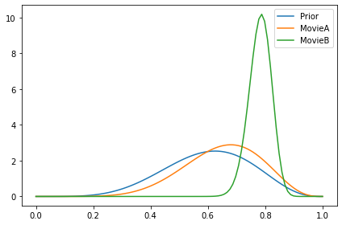

```python
from scipy.stats import beta

comp_xs = np.linspace(0, 1, 100)

prior_a, prior_b = 6, 4
prior_ys = list(map(lambda x: beta.pdf(x, prior_a, prior_b), comp_xs))

moviea_stars = 4 + 5
moviea_reviews = 2
moviea_avg = moviea_stars / (moviea_reviews * 5)
moviea_posterior_alpha = prior_a + (moviea_avg * moviea_reviews)
moviea_posterior_beta = prior_b + ((1 - moviea_avg) * moviea_reviews)

movieb_stars = 4 * 100
movieb_reviews = 100
movieb_avg = movieb_stars / (movieb_reviews * 5)
movieb_posterior_alpha = prior_a + (movieb_avg * movieb_reviews)
movieb_posterior_beta = prior_b + ((1 - movieb_avg) * movieb_reviews)

moviea_ys = list(map(lambda x: beta.pdf(x, moviea_posterior_alpha, moviea_posterior_beta), comp_xs))
movieb_ys = list(map(lambda x: beta.pdf(x, movieb_posterior_alpha, movieb_posterior_beta), comp_xs))

fig, axes = plt.subplots()
axes.plot(comp_xs, prior_ys, label="Prior")
axes.plot(comp_xs, moviea_ys, label="MovieA")
axes.plot(comp_xs, movieb_ys, label="MovieB")
axes.legend()

fig.tight_layout()
plt.show()
```

This appears to align with my thinking - movie A looks a little above average, but we're not really sure. We are very certain that movie B is above average. If we ranked these movies based on their mean value:

```python
moviea_mean = moviea_posterior_alpha / (moviea_posterior_alpha + moviea_posterior_beta)
print("Movie A posterior mean: ", moviea_mean)
movieb_mean = movieb_posterior_alpha / (movieb_posterior_alpha + movieb_posterior_beta)
print("Movie B posterior mean: ", movieb_mean)
```

```
Movie A posterior mean:  0.65
Movie B posterior mean:  0.7818181818181819
```

We would rank movie B much farther ahead.

The next task will be to calculate the prior. We can use the entire dataset to fit a beta distribution:

```python
review_num_df = rating_df.groupby(["movie_id"]).size().to_frame(name="review_num")
rating_sum_df = rating_df.groupby(["movie_id"]).agg({"rating": ["sum"]})
rating_sum_df.columns = ["rating_sum"]
alt_movies_df = movie_df.merge(
    review_num_df,
    left_on="movie_id",
    right_on="movie_id",
    how="inner"
).merge(
    rating_sum_df,
    left_on="movie_id",
    right_on="movie_id",
    how="inner"
)
alt_movies_df["avg_score"] = alt_movies_df["rating_sum"] / (alt_movies_df["review_num"] * 5)
alt_movies_df.sort_values("review_num", ascending=False).head(n=10)
# calculate average score and fit beta distribution
avg_scores = list(map(lambda x: min(max(x, 0.0001), 0.9999), alt_movies_df["avg_score"]))
beta_fit = beta.fit(avg_scores, floc=0, fscale=1)
print(beta_fit)
```

```
(6.902702095082328, 3.7478782800043087, 0, 1)
```

Now we can use this beta distribution to calculate a posterior score for each movie. Let's do this and look at the top 10 movies based on this score.

```python
prior_a, prior_b = beta_fit[0], beta_fit[1]
post_movies_df = alt_movies_df.copy()
post_movies_df["post_a"] = prior_a + (post_movies_df["avg_score"] * post_movies_df["review_num"])
post_movies_df["post_b"] = prior_a + ((1 - post_movies_df["avg_score"]) * post_movies_df["review_num"])
post_movies_df["post_mean"] = post_movies_df["post_a"] / (post_movies_df["post_a"] + post_movies_df["post_b"])
post_movies_df.sort_values("post_mean", ascending=False).head(n=10)
```

| movie_id | title | genres | review_num | rating_sum | avg_score | post_a | post_b | post_mean |
| --- | --- | --- | --- | --- | --- | --- | --- | --- |
| 318 | Shawshank Redemption, The (1994) | Drama | 2227 | 10143 | 0.910912 | 2035.502702 | 205.302702 | 0.908380 |
| 2019 | Seven Samurai (The Magnificent Seven) (Shichin... | Action\|Drama | 628 | 2864 | 0.912102 | 579.702702 | 62.102702 | 0.903237 |
| 858 | Godfather, The (1972) | Action\|Crime\|Drama | 2223 | 10059 | 0.904993 | 2018.702702 | 218.102702 | 0.902494 |
| 50 | Usual Suspects, The (1995) | Crime\|Thriller | 1783 | 8054 | 0.903421 | 1617.702702 | 179.102702 | 0.900322 |
| 527 | Schindler's List (1993) | Drama\|War | 2304 | 10392 | 0.902083 | 2085.302702 | 232.502702 | 0.899688 |
| 745 | Close Shave, A (1995) | Animation\|Comedy\|Thriller | 657 | 2970 | 0.904110 | 600.902702 | 69.902702 | 0.895793 |
| 1148 | Wrong Trousers, The (1993) | Animation\|Comedy | 882 | 3976 | 0.901587 | 802.102702 | 93.702702 | 0.895398 |
| 1198 | Raiders of the Lost Ark (1981) | Action\|Adventure | 2514 | 11257 | 0.895545 | 2258.302702 | 269.502702 | 0.893385 |
| 904 | Rear Window (1954) | Mystery\|Thriller | 1050 | 4700 | 0.895238 | 946.902702 | 116.902702 | 0.890109 |
| 260 | Star Wars: Episode IV - A New Hope (1977) | Action\|Adventure\|Fantasy\|Sci-Fi | 2991 | 13321 | 0.890739 | 2671.102702 | 333.702702 | 0.888944 |

Now this is looking like a good list! Not only are all of these movies very popular, but they have very high average scores. If we used this ranking on the action genre, our top ten movies would be:

```python
action_movies_quality_df = genre_df[genre_df.genre == "Action"].merge(
    movie_df,
    left_on="movie_id",
    right_on="movie_id",
    how="inner"
).merge(
    post_movies_df[["post_mean"]],
    left_on="movie_id",
    right_on="movie_id",
    how="inner"
)
action_movies_quality_df.sort_values('post_mean', ascending=False).head(n=10)
```

| movie_id | genre | title | genres | post_mean |
| --- | --- | --- | --- | --- |
| 2019 | Action | Seven Samurai (The Magnificent Seven) (Shichin... | Action\|Drama | 0.903237 |
| 858 | Action | Godfather, The (1972) | Action\|Crime\|Drama | 0.902494 |
| 1198 | Action | Raiders of the Lost Ark (1981) | Action\|Adventure | 0.893385 |
| 260 | Action | Star Wars: Episode IV - A New Hope (1977) | Action\|Adventure\|Fantasy\|Sci-Fi | 0.888944 |
| 1221 | Action | Godfather: Part II, The (1974) | Action\|Crime\|Drama | 0.868506 |
| 2028 | Action | Saving Private Ryan (1998) | Action\|Drama\|War | 0.865568 |
| 2571 | Action | Matrix, The (1999) | Action\|Sci-Fi\|Thriller | 0.861241 |
| 1197 | Action | Princess Bride, The (1987) | Action\|Adventure\|Comedy\|Romance | 0.858606 |
| 1196 | Action | Star Wars: Episode V - The Empire Strikes Back... | Action\|Adventure\|Drama\|Sci-Fi\|War | 0.856947 |
| 1233 | Action | Boat, The (Das Boot) (1981) | Action\|Drama\|War | 0.855635 |

This list has some of the same movies as our original popularity only list (Star Wars, The Matrix), but also contains some of the most acclaimed movies (that also are marked as the action genre) like Seven Samurai, The Godfather, and Raiders of the Lost Ark. This new system seems to incorporate both popularity and quality, and I think would make a good system for recommending movies within a genre.

## System II

Next we will try to make recommendations using collaborative filtering. The difference between this and system I is that instead of the user providing a genre and us making recommendations within that genre, the user provides their ratings for several movies and we recommend movies out of all the possible movies based on their previous preferences.

### Collaborative Filtering Algorithm

Collaborative filtering is a way of estimating what score a user would give each movie, in particular movies they haven't rated. We can then recommend movies that we estimate they would give a high rating to. The "collaborative" portion of this refers to the algorithm finding either items or users that are similar, and using their observed scores to estimate scores for unobserved values.

### Implementation

To implement CF we will be using the `surprise` package in python. We'll want to compare multiple approaches, so we'll need a scoring method, for which I will propose RMSE.

```python
from surprise import Dataset
from surprise import Reader

df = rating_df.copy()
df.reset_index(level=0, inplace=True)

reader = Reader(rating_scale=(1, 5))

# The columns must correspond to user id, item id and ratings (in that order).
data = Dataset.load_from_df(df[["user_id", "movie_id", "rating"]], reader)
```

Now we can try 10-fold cross validation with this algorithm on the dataset, and report on the RMSE:

```python
from surprise import KNNBasic
from surprise.model_selection import cross_validate

algo_knn = KNNBasic()
result = cross_validate(algo_knn, data, measures=['RMSE'], cv=10, verbose=True)
```

```
Computing the msd similarity matrix...
Done computing similarity matrix.
Computing the msd similarity matrix...
Done computing similarity matrix.
Computing the msd similarity matrix...
Done computing similarity matrix.
Computing the msd similarity matrix...
Done computing similarity matrix.
Computing the msd similarity matrix...
Done computing similarity matrix.
Computing the msd similarity matrix...
Done computing similarity matrix.
Computing the msd similarity matrix...
Done computing similarity matrix.
Computing the msd similarity matrix...
Done computing similarity matrix.
Computing the msd similarity matrix...
Done computing similarity matrix.
Computing the msd similarity matrix...
Done computing similarity matrix.
Evaluating RMSE of algorithm KNNBasic on 10 split(s).

                  Fold 1  Fold 2  Fold 3  Fold 4  Fold 5  Fold 6  Fold 7  Fold 8  Fold 9  Fold 10 Mean    Std
RMSE (testset)    0.9187  0.9193  0.9189  0.9143  0.9186  0.9180  0.9154  0.9141  0.9181  0.9211  0.9176  0.0022
Fit time          41.28   43.78   43.26   44.65   43.61   45.12   43.47   42.68   44.27   47.08   43.92   1.46
Test time         55.10   55.93   56.12   55.60   55.99   56.09   56.36   56.23   64.32   64.69   57.64   3.45
```

This approach was able to get a RMSE value of around 0.91. I didn't hypertune any of the parameters of the `KNN` algorithm, but it will do things like determine the most appropriate k-size. The results could possibly be improved with some tuning.

Another algorithm we can try is singular value decomposition (SVD), which may improve the accuracy of our predictions. This is a matrix factorization approach that tries to decompose the prediction matrix as a product of two other matrices. With the [SVD implementation](https://surprise.readthedocs.io/en/stable/matrix_factorization.html#surprise.prediction_algorithms.matrix_factorization.SVD) in `surprise`, the prediction is set as:

$\hat{r}_{ui} = \mu + b_u + b_i + q_i^Tp_u$

Ratings for users/items that are unknown are assumed to be zero. Now we are trying to learn the $q$ and $p$ vectors, which the algorithm uses stochastic gradient descent to minimize the regularized squared error calculated by:

$\Sigma_{r_{ui}\in R_{train}} (r_{ui} - \hat{r}_{ui})^{2} + \lambda (b_i^2 + b_u^2 + \parallel{q_i}\parallel^2 + \parallel{p_u}\parallel^2)$

With this approach we can try 10-fold cross-validation on our set and report the RMSE for each fold:

```python
from surprise import SVD

algo_svd = SVD()
result = cross_validate(algo_svd, data, measures=['RMSE'], cv=10, verbose=True)
```

```
Evaluating RMSE of algorithm SVD on 10 split(s).

                  Fold 1  Fold 2  Fold 3  Fold 4  Fold 5  Fold 6  Fold 7  Fold 8  Fold 9  Fold 10 Mean    Std
RMSE (testset)    0.8654  0.8673  0.8660  0.8638  0.8623  0.8627  0.8665  0.8684  0.8667  0.8682  0.8657  0.0021
Fit time          41.87   44.66   44.75   45.96   45.60   45.36   44.22   44.37   44.83   45.01   44.66   1.06
Test time         1.32    1.33    0.94    1.32    0.94    1.36    1.34    0.95    1.36    1.21    1.21    0.18
```

Using SVD we were able to get a mean RMSE of 0.8657, which is an improvement over kNN. It seems like we should try to use this approach for our recommendation application.

Now we need to be able to use this model to make new predictions, which will be like getting the top-n recommendations for a user. Since the best model so far is SVD, how can we use that to generate a prediction for users not in our dataset, like a new user? One approach we could take is to calculate the similarity of the new user to all the users in our dataset (based on the scores they provide). We could then use those similarities to create a weight for each user in the dataset, and use those weights to created a weighted average of the result of our SVD predictions. This would be similar to a user-based approach, but with the benefit of SVD, as well as being quite fast when making new predictions.

To accomplish this we first need a matrix that contains the estimate for every user for every movie in our dataset, based on the SVD model above. To do that we will re-train the model on the entire dataset, create predictions for every user/movie, and then save that as a matrix.

```python
# train SVD on the full set
trainset = data.build_full_trainset()
algo = SVD()
algo.fit(trainset)
```

```
<surprise.prediction_algorithms.matrix_factorization.SVD at 0x7f20adfac8e0>
```

```python
# build lookups since indexes arent sequential
movie_lookup = {}
movie_rev_lookup = {}
i = 0
for index, row in movie_df.iterrows():
    movie_lookup[index] = i
    movie_rev_lookup[i] = index
    i += 1
user_lookup = {}
user_rev_lookup = {}
i = 0
for index, row in user_df.iterrows():
    user_lookup[index] = i
    user_rev_lookup[i] = index
    i += 1
```

```python
# get predictions for every user/movie combination
from itertools import product

user_list = list(user_df.index)
movie_list = list(movie_df.index)
full_user_movie_combo = [(x[0], x[1], 3) for x in product(user_list, movie_list)]
```

```python
full_user_movie_combo_predictions = algo.test(full_user_movie_combo)
```

```python
n_users = len(user_df)
n_movies = len(movie_df)
# construct a matrix of estimate movie rankins for all users
movie_estimate_matrix = np.empty(shape=(n_users, n_movies))
movie_estimate_matrix[:] = np.nan
for p in full_user_movie_combo_predictions:
    movie_estimate_matrix[user_lookup[p.uid], movie_lookup[p.iid]] = p.est
```

We now have our matrix of score predictions. Let's assume we have a new user that has made no recommendations. Since we have no information on this user we would assume they are equally similar to every existing user we have, and their weights for each user would be identical:

```python
new_user_weights = np.full(n_users, 1/n_users)
```

We can now multiply each row of our estimate matrix by these weights, sum the columns, and get our estimated score for each movie:

```python
n_est = (movie_estimate_matrix.T * new_user_weights).T
n_est = n_est.sum(axis=0)
print(n_est)
```

```
[4.14921349 3.21387775 3.05785408 ... 3.66918861 3.97852032 3.82342063]
```

In this case this is also the average estimated score for each movie. Now we can sort this, and find their corresponding movie title:

```python
sorted_movies = list(np.argsort(n_est))
# argsort sorts in ascending order
sorted_movies.reverse()
movie_recs = [movie_rev_lookup[m_id] for m_id in sorted_movies]
for movie_rec in movie_recs[:10]:
    print(movie_df.loc[movie_rec].title)
```

```
Sanjuro (1962)
Shawshank Redemption, The (1994)
Schindler's List (1993)
Godfather, The (1972)
Seven Samurai (The Magnificent Seven) (Shichinin no samurai) (1954)
Close Shave, A (1995)
Rear Window (1954)
Usual Suspects, The (1995)
For All Mankind (1989)
Wrong Trousers, The (1993)
```

This list is very similar to our bayesian fit above (for any genre), which is good. The benefit to this particular approach is that we can now adjust the per-user weights based on a new users ratings, so let's try that now. Let's pretend we have a new user that is a fan of children movies like Toy Story, and disliked crime movies like the Godfather and The Usual Suspects. First we'll need a matrix of all users rankings that is centered.

```python
n_users = len(user_df)
n_movies = len(movie_df)
# construct a matrix of estimate movie rankins for all users
movie_rating_matrix = np.zeros(shape=(n_users, n_movies))
for index, row in rating_df.iterrows():
    movie_rating_matrix[user_lookup[index], movie_lookup[row["movie_id"]]] = row["rating"]
```

```python
movie_rating_matrix_means = movie_rating_matrix.sum(axis=1) / (movie_rating_matrix != 0).sum(axis=1)
movie_rating_matrix_centered = movie_rating_matrix.copy()
for row_i, row_mean in enumerate(movie_rating_matrix_means):
    for col_i in range(len(movie_rating_matrix_centered[row_i,])):
        if movie_rating_matrix_centered[row_i, col_i] != 0:
            movie_rating_matrix_centered[row_i, col_i] = movie_rating_matrix_centered[row_i, col_i] - row_mean
```

Now we'll need to calculate the similarity of our new users recommendations to every user in the dataset. To do this I'll use Pearsons correlation (aka centered cosine similarity). I'll define two help functions to do this:

```python
def centered_cosine_similarity(v1, v2):
    if np.linalg.norm(v2) == 0:
        return 0
    return np.matmul(v1.T, v2) / (np.linalg.norm(v1) * np.linalg.norm(v2))

def center_vector(v):
    v_copy = v.copy()
    v_mean = v.sum() / (v != 0).sum()
    for v_i, val in enumerate(v):
        if val != 0:
            v_copy[v_i] = val - v_mean
    return(v_copy)
```

Now we can get the vector and weights for our new user:

```python
test_user_rating = np.zeros(n_movies)
test_user_rating[movie_lookup[858]] = 1 # godfather
test_user_rating[movie_lookup[50]] = 1 # usual suspects
test_user_rating[movie_lookup[1]] = 5 # toy story 1
test_user_rating[movie_lookup[3114]] = 5 # toy story 2

test_user_rating_centered = center_vector(test_user_rating)
test_user_rating_centered
```

```
array([2., 0., 0., ..., 0., 0., 0.])
```

```python
sim_t = np.array([
    centered_cosine_similarity(test_user_rating_centered, user_vector)
    for user_vector
    in movie_rating_matrix_centered
])
kid_user_weights = sim_t
```

If a weight is positive that means that users preference is positively correlated with our new user. If we take the estimate matrix and center it, then positive estimates for users we correlate with will increase a movies ranking. Inversely if the new user negatively correlates with a particular movie, then movies they disliked will be increased. If a user has no correlation with a particular user (which would happen if they didn't review any of the same movies), then their weight would be around 0 and those estimated reviews will have no impact on our recommendations. We can now use these weights to score each movie in the dataset, and then get the top 10 for this particular user:

```python
movie_estimate_matrix_centered = np.zeros(shape=(n_users, n_movies))
user_row_means = movie_estimate_matrix.mean(axis=1)
for user_id in range(n_users):
    movie_estimate_matrix_centered[user_id,] = movie_estimate_matrix[user_id,] - user_row_means[user_id]
```

```python
n_est = (movie_estimate_matrix_centered.T * kid_user_weights).T
n_est = n_est.sum(axis=0)
sorted_movies = list(np.argsort(n_est))
# argsort sorts in ascending order
sorted_movies.reverse()
movie_recs = [movie_rev_lookup[m_id] for m_id in sorted_movies]
for movie_rec in movie_recs[:10]:
    print(movie_df.loc[movie_rec].title)
```

```
Battlefield Earth (2000)
Kazaam (1996)
3 Ninjas: High Noon On Mega Mountain (1998)
Barney's Great Adventure (1998)
Turbo: A Power Rangers Movie (1997)
Stop! Or My Mom Will Shoot (1992)
Super Mario Bros. (1993)
Digimon: The Movie (2000)
Iron Eagle IV (1995)
Baby Geniuses (1999)
```

This list looks appropriate for pur hypothetical user, i.e. it contains mostly childrens movies and no crime or adult themed movies. We were also able to generate this list from only 4 reviews from the user, which would be ideal for our web application (since then we don't have to ask the user to review many movies before making a recommendation).

We can also try flipping those ratings - i.e. if we liked crime movies but disliked children's movies:

```python
test_user_rating = np.zeros(n_movies)
test_user_rating[movie_lookup[858]] = 5 # godfather
test_user_rating[movie_lookup[50]] = 5 # usual suspects
test_user_rating[movie_lookup[1]] = 1 # toy story 1
test_user_rating[movie_lookup[3114]] = 1 # toy story 2

test_user_rating_centered = center_vector(test_user_rating)
test_user_rating_centered

sim_t = np.array([
    centered_cosine_similarity(test_user_rating_centered, user_vector)
    for user_vector
    in movie_rating_matrix_centered
])
kid_user_weights = sim_t

n_est = (movie_estimate_matrix_centered.T * kid_user_weights).T
n_est = n_est.sum(axis=0)
sorted_movies = list(np.argsort(n_est))
# argsort sorts in ascending order
sorted_movies.reverse()
movie_recs = [movie_rev_lookup[m_id] for m_id in sorted_movies]
for movie_rec in movie_recs[:10]:
    print(movie_df.loc[movie_rec].title)
```

```
Godfather, The (1972)
Godfather: Part II, The (1974)
One Flew Over the Cuckoo's Nest (1975)
Usual Suspects, The (1995)
American Beauty (1999)
Sanjuro (1962)
Pulp Fiction (1994)
Apocalypse Now (1979)
GoodFellas (1990)
Shawshank Redemption, The (1994)
```

More crime/classic movies (this didn't remove movies we already ranked, but that's something we'd want the web application to do).

It looks like by using the two matrices (movie estimates, centered rankings) we should be able to quickly make new recommendations (this code takes < 1 second on my computer, and < 10 seconds on the web server), so we'll save those two to files. Each matrix is around 187MB in size, and github (where I'm hosting the code/site) has a 100MB file size limit, so I've split each into two files. They are saved like this:

```python
# movie_estimate_matrix_centered
movie_estimate_matrix_centered_pieces = np.vsplit(movie_estimate_matrix_centered, 2)
np.save('movie_estimate_matrix_centered-0.npy', movie_estimate_matrix_centered_pieces[0])
np.save('movie_estimate_matrix_centered-1.npy', movie_estimate_matrix_centered_pieces[1])
# movie_rating_matrix_centered
movie_rating_matrix_centered_pieces = np.vsplit(movie_rating_matrix_centered, 2)
np.save('movie_rating_matrix_centered-0.npy', movie_rating_matrix_centered_pieces[0])
np.save('movie_rating_matrix_centered-1.npy', movie_rating_matrix_centered_pieces[1])
```

## Web App

The final component to this project is a web application that allows users to get movie recommendations based on their genre preference or based on a series of movie ratings. To build this website I will be using the [Flask](https://flask.palletsprojects.com/en/1.1.x/) python framework, and deploying it on [Heroku](https://www.heroku.com/).

The system I recommendations can be entirely pre-computed (i.e. create a top-10 list for each genre and save that), which I can save as a CSV file that is read and rendered to HTML each time the user requests the website. Let's generate the top movies for each genre and save it as a CSV:

```python
genres = genre_df.genre.unique()
top_10s = []
for genre in genres:
    candidate_df = genre_df[genre_df.genre == genre].merge(
        post_movies_df,
        left_on="movie_id",
        right_on="movie_id",
        how="inner"
    ).sort_values("post_mean", ascending=False).head(n=10)
    top_10s.append(candidate_df)

top10_df = pd.concat(top_10s)
top10_df.to_csv("top10_by_genre.csv")
top10_df.head(n=11)
```

| movie_id | genre | title | genres | review_num | rating_sum | avg_score | post_a | post_b | post_mean |
| --- | --- | --- | --- | --- | --- | --- | --- | --- | --- |
| 745 | Animation | Close Shave, A (1995) | Animation\|Comedy\|Thriller | 657 | 2970 | 0.904110 | 600.902702 | 69.902702 | 0.895793 |
| 1148 | Animation | Wrong Trousers, The (1993) | Animation\|Comedy | 882 | 3976 | 0.901587 | 802.102702 | 93.702702 | 0.895398 |
| 720 | Animation | Wallace & Gromit: The Best of Aardman Animatio... | Animation | 438 | 1939 | 0.885388 | 394.702702 | 57.102702 | 0.873612 |
| 1223 | Animation | Grand Day Out, A (1992) | Animation\|Comedy | 473 | 2063 | 0.872304 | 419.502702 | 67.302702 | 0.861746 |
| 3429 | Animation | Creature Comforts (1990) | Animation\|Comedy | 274 | 1188 | 0.867153 | 244.502702 | 43.302702 | 0.849542 |
| 3114 | Animation | Toy Story 2 (1999) | Animation\|Children's\|Comedy | 1585 | 6687 | 0.843785 | 1344.302702 | 254.502702 | 0.840817 |
| 1 | Animation | Toy Story (1995) | Animation\|Children's\|Comedy | 2077 | 8613 | 0.829369 | 1729.502702 | 361.302702 | 0.827194 |
| 3000 | Animation | Princess Mononoke, The (Mononoke Hime) (1997) | Action\|Adventure\|Animation | 345 | 1431 | 0.829565 | 293.102702 | 65.702702 | 0.816885 |
| 741 | Animation | Ghost in the Shell (Kokaku kidotai) (1995) | Animation\|Sci-Fi | 314 | 1284 | 0.817834 | 263.702702 | 64.102702 | 0.804449 |
| 2761 | Animation | Iron Giant, The (1999) | Animation\|Children's | 674 | 2728 | 0.809496 | 552.502702 | 135.302702 | 0.803283 |
| 919 | Children's | Wizard of Oz, The (1939) | Adventure\|Children's\|Drama\|Musical | 1718 | 7298 | 0.849593 | 1466.502702 | 265.302702 | 0.846806 |

This CSV file can now be stored with the web application. The site can load it and generate HTML that shows the list, and use Javascript to show/hide each genre based on the user selection. This can be seen at [recotron.herokuapp.com](https://recotron.herokuapp.com/).

Next is the recommendation based on the users ratings. The code above showed how this can be done, but I'll include all the relevant code to do that here (other than the movie lookup, which can be retrieved directly from the input file).

```python
test_user_rating = np.zeros(n_movies)
test_user_rating[movie_lookup[260]] = 5 # star wars IV
test_user_rating[movie_lookup[1196]] = 5 # star wars V
test_user_rating[movie_lookup[1]] = 1 # toy story 1
test_user_rating[movie_lookup[3114]] = 1 # toy story 2

def center_vector(v):
    v_copy = v.copy()
    v_mean = v.sum() / (v != 0).sum()
    for v_i, val in enumerate(v):
        if val != 0:
            v_copy[v_i] = val - v_mean
    return(v_copy)

test_user_rating_centered = center_vector(test_user_rating)

def centered_cosine_similarity(v1, v2):
    if np.linalg.norm(v2) == 0:
        return 0
    return np.matmul(v1.T, v2) / (np.linalg.norm(v1) * np.linalg.norm(v2))

m_p0 = np.load('movie_rating_matrix_centered-0.npy')
m_p1 = np.load('movie_rating_matrix_centered-1.npy')
movie_rating_matrix_centered = np.concatenate((m_p0, m_p1))
m_p0, m_p1 = None, None
new_user_weights = np.array([
    centered_cosine_similarity(test_user_rating_centered, user_vector)
    for user_vector
    in movie_rating_matrix_centered
])
movie_rating_matrix_centered = None # allow GC if memory is short

m_p0 = np.load('movie_estimate_matrix_centered-0.npy')
m_p1 = np.load('movie_estimate_matrix_centered-1.npy')
movie_estimate_matrix_centered = np.concatenate((m_p0, m_p1))
m_p0, m_p1 = None, None
n_est = (movie_estimate_matrix_centered.T * new_user_weights).T
n_est = n_est.sum(axis=0)
sorted_movies = list(np.argsort(n_est))
# argsort sorts in ascending order
sorted_movies.reverse()
movie_recs = [movie_rev_lookup[m_id] for m_id in sorted_movies]
for movie_rec in movie_recs[:10]:
    print(movie_df.loc[movie_rec].title)
```

```
Star Wars: Episode IV - A New Hope (1977)
Star Wars: Episode V - The Empire Strikes Back (1980)
Shawshank Redemption, The (1994)
Raiders of the Lost Ark (1981)
Sanjuro (1962)
Star Wars: Episode VI - Return of the Jedi (1983)
Godfather, The (1972)
Usual Suspects, The (1995)
Matrix, The (1999)
Schindler's List (1993)
```

We'll need the users to rate some movies. Ideally we will ask them to rate movies they've seen. It could be possible to generate this list randomly each time, but for this project I'll just sample 20 movies from the top 100 most reviewed movies and use the same list each time. Getting that sample:

```python
movie_sample = post_movies_df.sort_values("review_num", ascending=False).head(n=100).sample(n=20)
list(zip(movie_sample.index, movie_sample.title))
```

```
[(1259, 'Stand by Me (1986)'),
 (380, 'True Lies (1994)'),
 (2997, 'Being John Malkovich (1999)'),
 (2406, 'Romancing the Stone (1984)'),
 (1307, 'When Harry Met Sally... (1989)'),
 (541, 'Blade Runner (1982)'),
 (2804, 'Christmas Story, A (1983)'),
 (1923, "There's Something About Mary (1998)"),
 (858, 'Godfather, The (1972)'),
 (1304, 'Butch Cassidy and the Sundance Kid (1969)'),
 (1784, 'As Good As It Gets (1997)'),
 (2396, 'Shakespeare in Love (1998)'),
 (34, 'Babe (1995)'),
 (3114, 'Toy Story 2 (1999)'),
 (1193, "One Flew Over the Cuckoo's Nest (1975)"),
 (1617, 'L.A. Confidential (1997)'),
 (2599, 'Election (1999)'),
 (110, 'Braveheart (1995)'),
 (318, 'Shawshank Redemption, The (1994)'),
 (924, '2001: A Space Odyssey (1968)')]
```

Just one note that I had sampled this list multiple times when developing the application so the list on the web application is different, but this was the process that was used to generate it.

The source code for the web application is available at https://github.com/kyledemeule/recotron. The most relevant or interesting files would be:

- app.py
  - Code for all the endpoints, including the recommendation endpoint [/rating/recommendation](https://github.com/kyledemeule/recotron/blob/master/app.py#L62)
- layout.html
  - Base HTML as well as javascript that reads user input and gets recommendations from server.

## References

Here is a list of the major tools I used to build the web application:

- [Surprise](http://surpriselib.com/)
  - Used for collaborative filtering in Python.
- [Pandas](https://pandas.pydata.org/)
  - Used for dataframes
- [Numpy](https://numpy.org/)
  - Used for numerical operations in Python like matrix calculations.
- [Flask](https://flask.palletsprojects.com/en/1.1.x/)
  - Web application framework in Pyhon used for building the website.

## Group Members

This project was completed by Kyle Demeule (NetID: demeule2)